# Surprises in time series analysis

Rob J Hyndman

26 October 2026

`robjhyndman.com/uconn2026`

## Three types of surprise

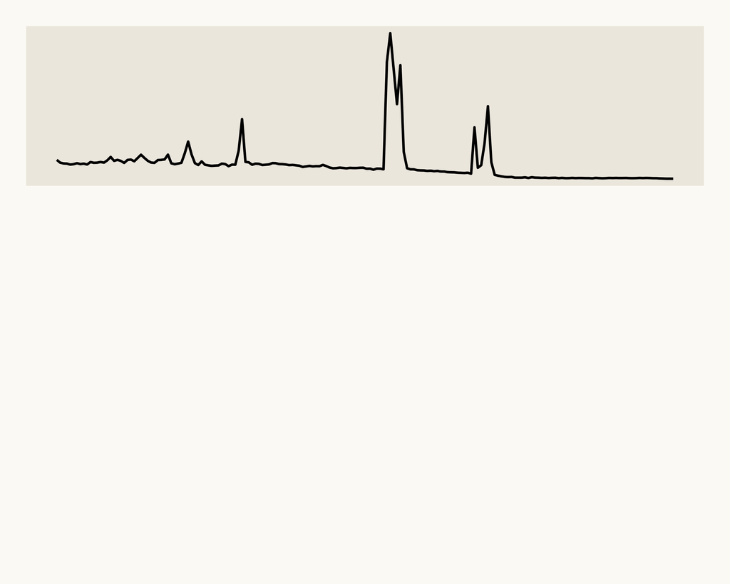

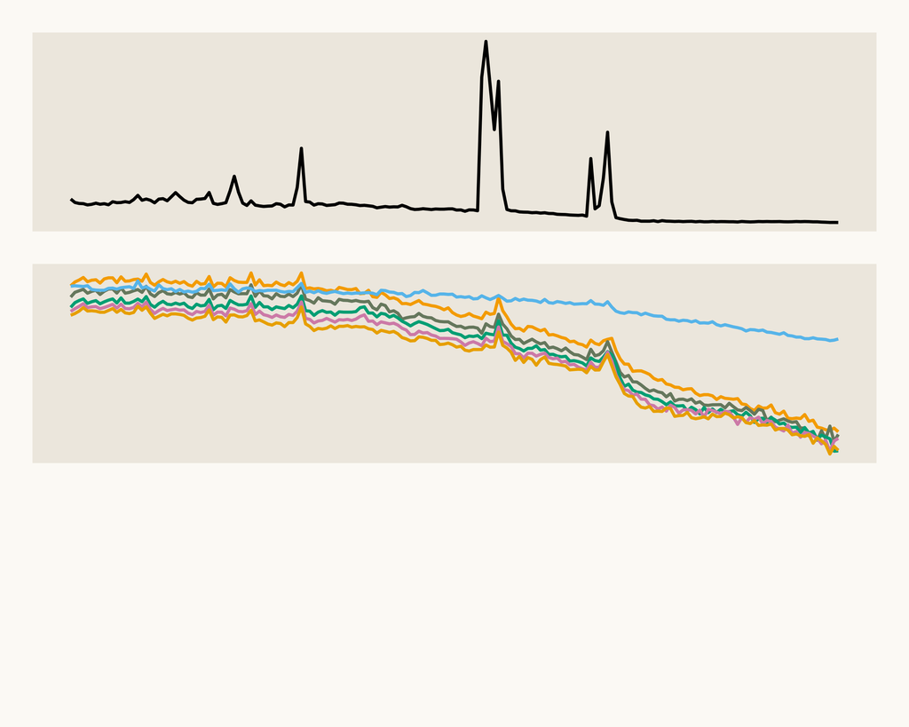

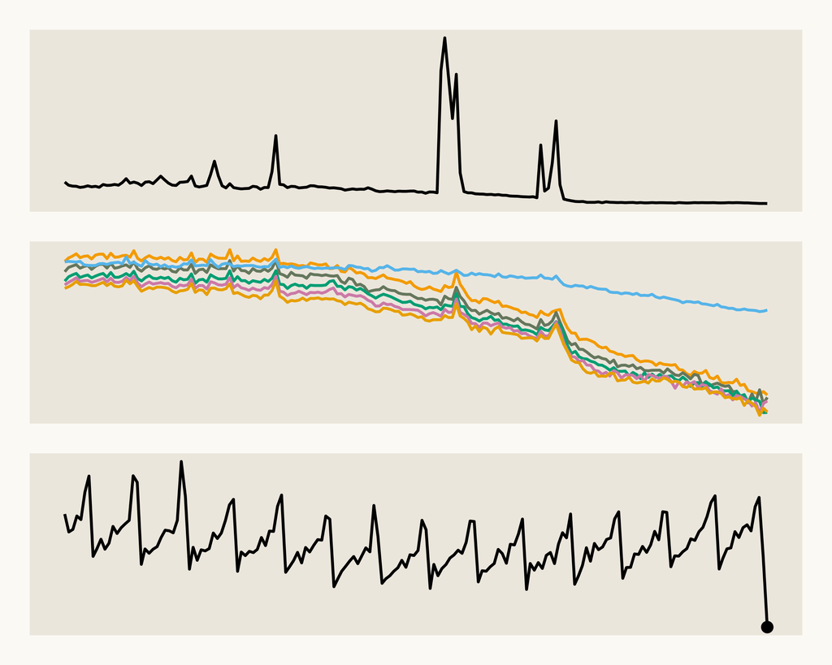

**Weird times**: unusual observations in a historical series

**Weird series**: an unusual series in a collection

**Surveillance**: an unusual observation just arrived

## Outline

1. Surprisals
2. Weird times
3. Weird series
4. Surveillance
5. Summary

## Surprisals

01

1. Surprisals
2. Weird times
3. Weird series
4. Surveillance
5. Summary

## Surprisal probabilities

The probability of an observation at least as unlikely as $y_t$ under density $f$:

$$p_t = \mathbb{P}\big(f(Y) \le f(y_t)\big), \qquad Y \sim f$$

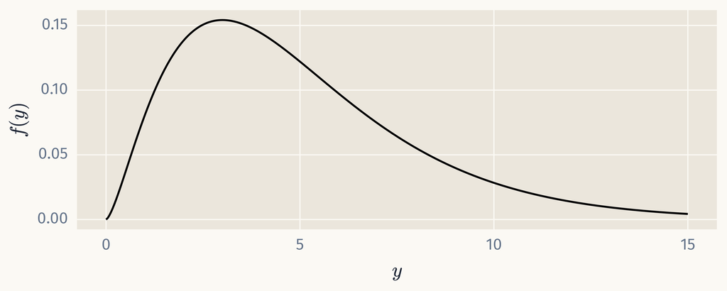

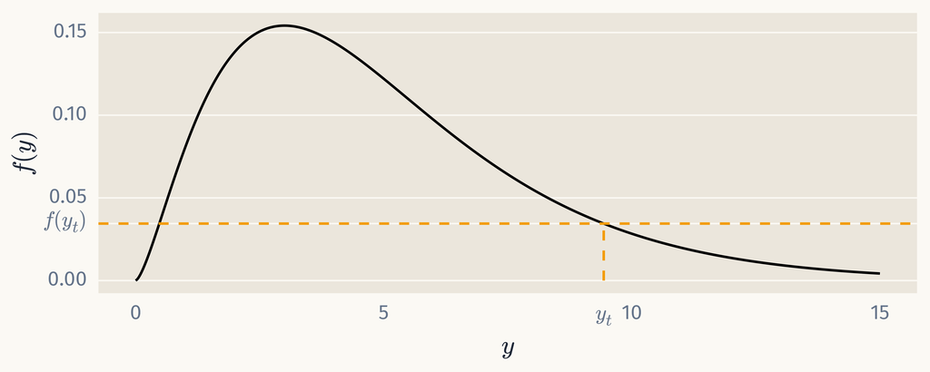

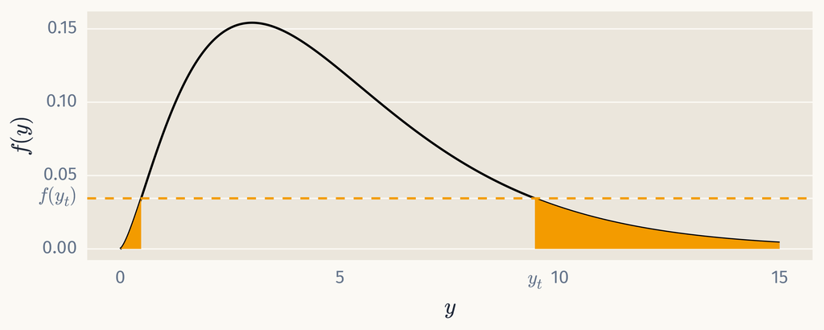

An observation is an **anomaly with respect to $f$** if $p_t < \alpha$.

## Surprisals

The **surprisal** of an observation $y_t$ under density $f$ is $s_t = -\log f(y_t)$

Surprisals are already familiar:

Forecasting

Log score for evaluating density forecasts

Information theory

Expected surprisal = entropy

Likelihood

Sum of surprisals = $-$log likelihood

Let $S = -\log f(Y)$ where $Y \sim f$, and $G(s) = \mathbb{P}(S \le s)$.  
Then $p_t = \mathbb{P}(S \ge s_t) = 1 - G(s_t)$.

An anomaly is an extreme value of the surprisal distribution.

$f$may be complicated

Multimodal, multivariate or conditional: $G$ is still a univariate distribution on $\mathbb{R}$.

$f$may be wrong

The upper tail probabilities of $G$ can be estimated using EVT.

## Surprisals have GPD tails

Theorem: surprisals have Generalised Pareto Distribution (GPD) tails

If the upper tail of $S = -\log f(Y)$ is smooth, then as the threshold $u$ grows,

$$\mathbb{P}\left( \frac{S - u}{a(u)} \le y \;\middle|\; S > u \right)
\longrightarrow
\begin{cases}
1 - (1 + \xi y)_+^{-1/\xi}, & \xi \ne 0,\\
1 - e^{-y}, & \xi = 0.
\end{cases}$$

$\xi < 0$: finite endpoint

$S$ bounded above  
e.g., truncated Normal data

$\xi = 0$: exponential tail

$\mathbb{E}\,e^{\lambda S} < \infty$  
e.g., Normal or $t$ data

$\xi > 0$: Pareto tail

Only $\mathbb{E}\,S^q < \infty$, with $\xi \le 1/q$  
e.g., $t$ data, Normal $f$

Conditions are on $S$, not $Y$: they hold even if $f$ is wrong.

## Approximate GPD surprisal probabilities

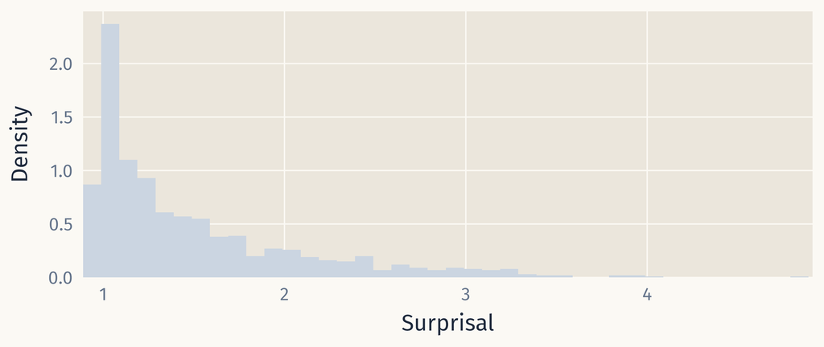

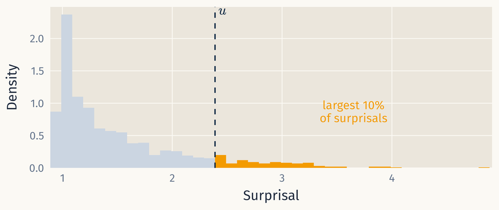

[video not shown]

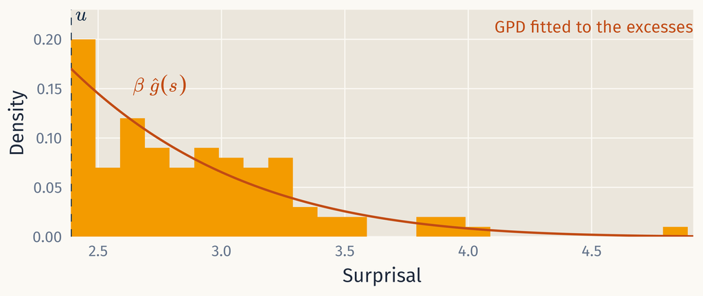

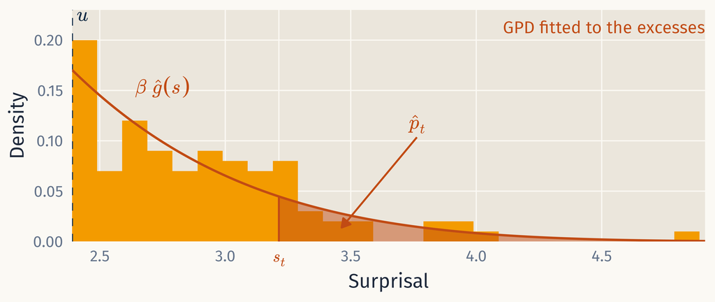

Only needs $f$ to get the *ordering* of the extreme surprisals correct.

## Univariate experiment

What happens when $f$ is mis-specified?

Data

1000 observations from N(0,1), and 1000 from t(4)

Surprisals

Computed under N(0,1) and under t(4)

Probabilities

From $f$ itself, or from a GPD fitted to the surprisals

## Univariate experiment

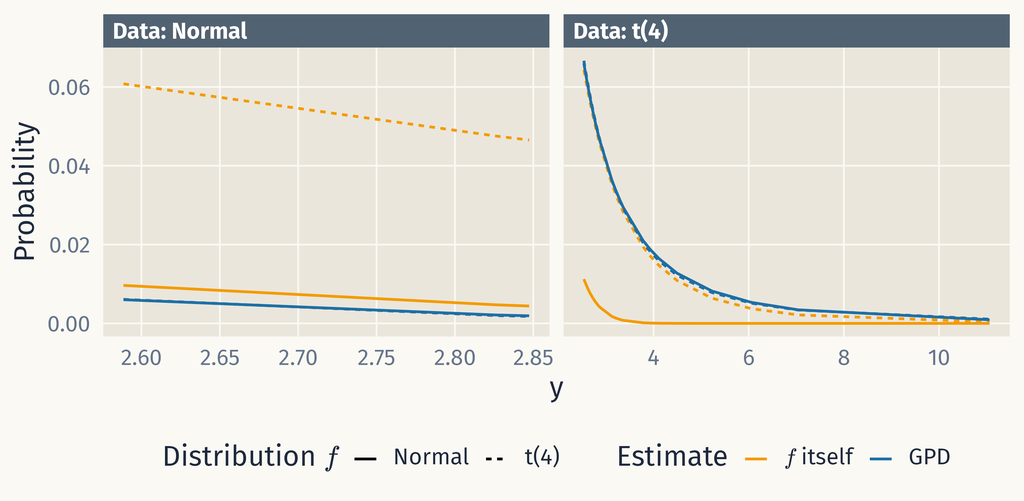

## Weird times

02

1. Surprisals
2. Weird times
3. Weird series
4. Surveillance
5. Summary

## French mortality rates

```r
library(weird)
fr_mortality
```

```
# A tibble: 31,648 × 4
   Year   Age Sex    Mortality
  <int> <int> <chr>      <dbl>
1  1816     0 Female    0.187
2  1816     1 Female    0.0467
3  1816     2 Female    0.0339
4  1816     3 Female    0.0229
5  1816     4 Female    0.0160
6  1816     5 Female    0.0138
7  1816     6 Female    0.0121
8  1816     7 Female    0.0104
# ℹ 31,640 more rows
```

- Annual data: 1816–1999
- Ages 0–85, by sex

## French mortality rates

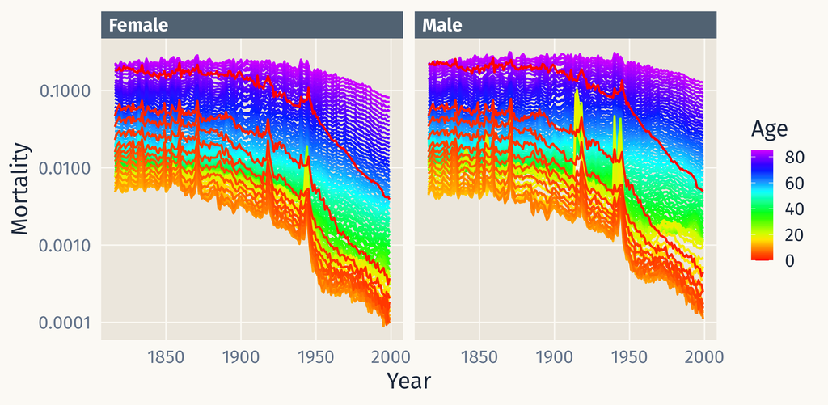

## Hampel identifier

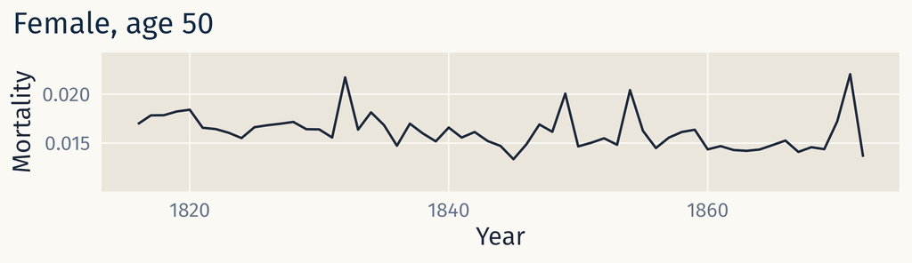

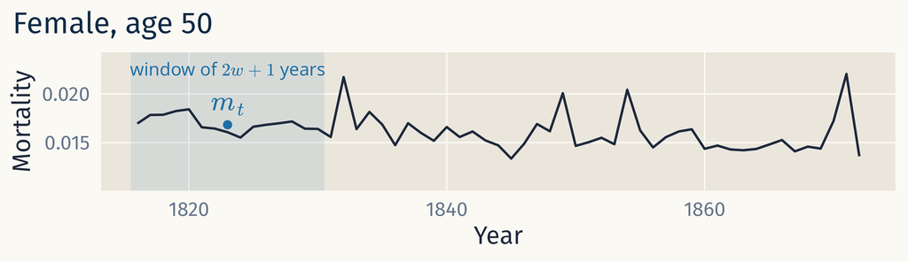

[video not shown]

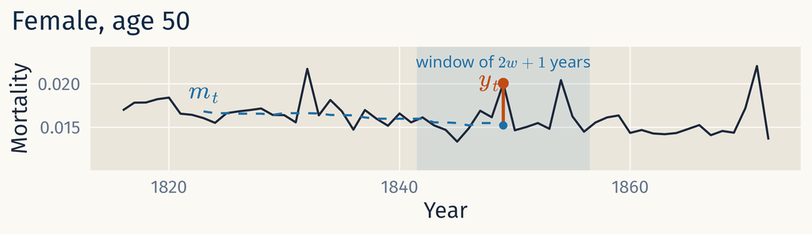

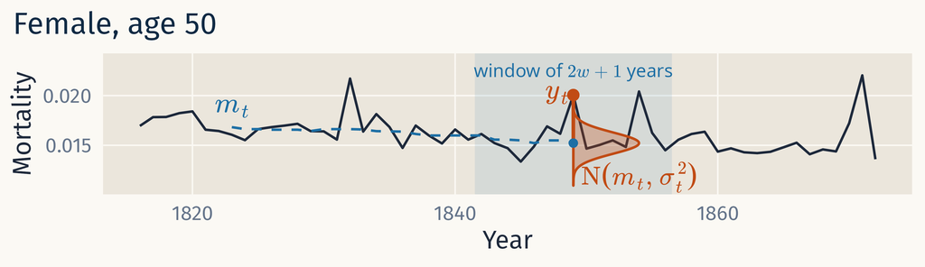

$$m_t = \text{median}(y_{t-w}, \dots, y_{t+w})$$

$$a_t = \text{median}(|y_{t-w} - m_t|, \dots, |y_{t+w} - m_t|)$$

- Anomaly if $|y_t - m_t| > ka_t$
- Implicit model: $y_t \sim \text{N}(m_t, \sigma_t^2)$ with $\sigma_t = a_t/0.6745$
- Better: compute surprisals under Normal, with probabilities from GPD

## French mortality rates

```r
fr_anomalies <- fr_mortality |>
  group_by(Age, Sex) |>
  mutate(
    hampel = hampel_anomalies(
      Mortality,
      bandwidth = 7,
      alpha = 0.01,
      approximation = "gpd"
    )
  ) |>
  ungroup() |>
  filter(hampel)
```

```r
fr_anomalies |>
  count(Year, Sex) |>
  filter(n >= 3)
```

```
# A tibble: 328 × 5
    Year   Age Sex    Mortality hampel
   <int> <int> <chr>      <dbl> <lgl>
 1  1832    40 Female    0.0167 TRUE
 2  1832    42 Female    0.0171 TRUE
 3  1832    45 Female    0.0174 TRUE
 4  1832    47 Female    0.0191 TRUE
 5  1832    49 Female    0.0206 TRUE
 6  1832    50 Female    0.0217 TRUE
 7  1832    52 Female    0.0242 TRUE
 8  1832    53 Female    0.0253 TRUE
 9  1832    54 Female    0.0264 TRUE
10  1832    55 Female    0.0277 TRUE
11  1832    59 Female    0.0365 TRUE
12  1832    60 Female    0.0403 TRUE
13  1832    61 Female    0.0445 TRUE
14  1832    62 Female    0.0481 TRUE
15  1832    64 Female    0.0531 TRUE
# ℹ 313 more rows
```

```
# A tibble: 18 × 3
    Year Sex        n
   <int> <chr>  <int>
 1  1832 Female    21
 2  1832 Male      14
 3  1834 Female     4
 4  1834 Male       5
 5  1837 Female     9
 6  1837 Male       5
 7  1849 Female    14
 8  1849 Male       4
 9  1870 Female     4
10  1870 Male       8
11  1871 Female    64
12  1871 Male      51
13  1914 Male       8
14  1915 Male      12
15  1918 Female    35
16  1918 Male       9
17  1940 Female    11
18  1940 Male      11
```

## French mortality rates

[interactive chart not shown]

## US weekly mortality rates

```r
us_stmf
```

```
# A tsibble: 2,865 x 3 [1W]
# Key:       Age group [5]
      Week `Age group` Mortality
    <week> <chr>           <dbl>
1 2015 W02 0-14         0.000522
2 2015 W03 0-14         0.000537
3 2015 W04 0-14         0.000532
4 2015 W05 0-14         0.000526
5 2015 W06 0-14         0.000494
6 2015 W07 0-14         0.000528
7 2015 W08 0-14         0.000530
8 2015 W09 0-14         0.000522
# ℹ 2,857 more rows
```

- Weekly data: 2015 W02 to 2025 W52
- 5 age groups: 0-14, 15-64, 65-74, 75-84, 85+

## US weekly mortality rates

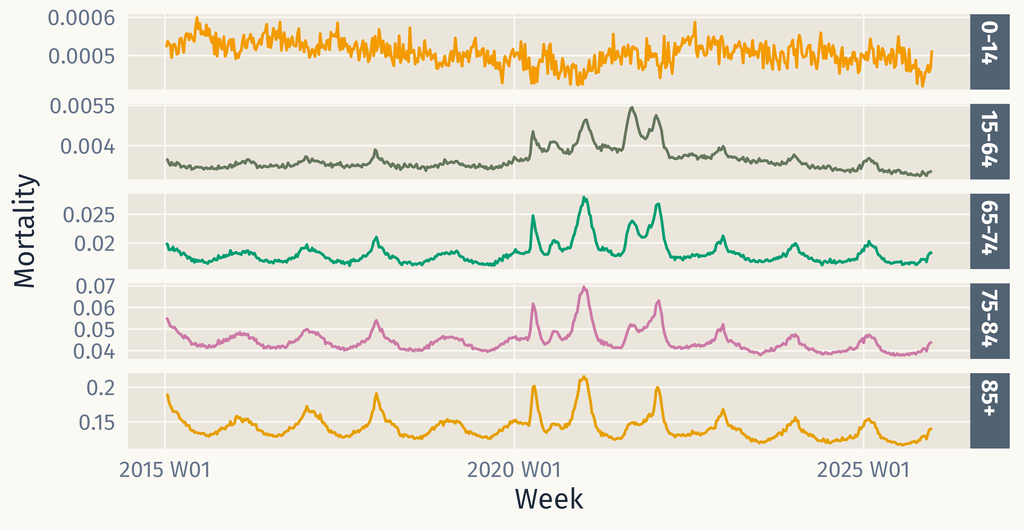

## Surprisals from an STL decomposition

Local medians fail with seasonality.

Use a better signal estimate:

- STL: $y_t = T_t + S_t + R_t$ (Cleveland et al., 1990; Bandara et al., 2025)
- $a$: robust scale of $R_t$ in each age group
- $e_t = R_t / a$; surprisals under N(0,1), probabilities from GPD

```r
stmf_scores <- us_stmf |>
  model(stl = STL(Mortality)) |> augment() |>
  group_by(`Age group`) |>
  mutate(
    a = robustbase::s_Qn(.resid),
    e = .resid / a
  ) |>
  ungroup() |>
  mutate(prob = surprisals_prob(e, "gpd", distribution = dist_normal())) |>
  arrange(prob)
```

```
# A tsibble: 2,865 x 4 [1W]
# Key:       Age group [5]
       Week `Age group` Mortality  .fitted
     <week> <chr>           <dbl>    <dbl>
 1 2015 W02 0-14         0.000522 0.000536
 2 2015 W02 15-64        0.00350  0.00352
 3 2015 W02 65-74        0.0200   0.0199
 4 2015 W02 75-84        0.0552   0.0534
 5 2015 W02 85+          0.190    0.178
 6 2015 W03 0-14         0.000537 0.000527
 7 2015 W03 15-64        0.00347  0.00349
 8 2015 W03 65-74        0.0197   0.0200
 9 2015 W03 75-84        0.0545   0.0535
10 2015 W03 85+          0.189    0.181
# ℹ 2,855 more rows
```

```
# A tsibble: 2,865 x 5 [1W]
# Key:       Age group [5]
       Week `Age group` Mortality  .fitted         a
     <week> <chr>           <dbl>    <dbl>     <dbl>
 1 2015 W02 0-14         0.000522 0.000536 0.0000202
 2 2015 W02 15-64        0.00350  0.00352  0.000123
 3 2015 W02 65-74        0.0200   0.0199   0.000649
 4 2015 W02 75-84        0.0552   0.0534   0.00156
 5 2015 W02 85+          0.190    0.178    0.00518
 6 2015 W03 0-14         0.000537 0.000527 0.0000202
 7 2015 W03 15-64        0.00347  0.00349  0.000123
 8 2015 W03 65-74        0.0197   0.0200   0.000649
 9 2015 W03 75-84        0.0545   0.0535   0.00156
10 2015 W03 85+          0.189    0.181    0.00518
# ℹ 2,855 more rows
```

```
# A tsibble: 2,865 x 6 [1W]
# Key:       Age group [5]
       Week `Age group` Mortality  .fitted         a      e
     <week> <chr>           <dbl>    <dbl>     <dbl>  <dbl>
 1 2015 W02 0-14         0.000522 0.000536 0.0000202 -0.684
 2 2015 W02 15-64        0.00350  0.00352  0.000123  -0.117
 3 2015 W02 65-74        0.0200   0.0199   0.000649   0.127
 4 2015 W02 75-84        0.0552   0.0534   0.00156    1.14
 5 2015 W02 85+          0.190    0.178    0.00518    2.25
 6 2015 W03 0-14         0.000537 0.000527 0.0000202  0.493
 7 2015 W03 15-64        0.00347  0.00349  0.000123  -0.163
 8 2015 W03 65-74        0.0197   0.0200   0.000649  -0.529
 9 2015 W03 75-84        0.0545   0.0535   0.00156    0.601
10 2015 W03 85+          0.189    0.181    0.00518    1.58
# ℹ 2,855 more rows
```

```
# A tsibble: 2,865 x 7 [1W]
# Key:       Age group [5]
       Week `Age group` Mortality  .fitted         a      e  prob
     <week> <chr>           <dbl>    <dbl>     <dbl>  <dbl> <dbl>
 1 2015 W02 0-14         0.000522 0.000536 0.0000202 -0.684   0.1
 2 2015 W02 15-64        0.00350  0.00352  0.000123  -0.117   0.1
 3 2015 W02 65-74        0.0200   0.0199   0.000649   0.127   0.1
 4 2015 W02 75-84        0.0552   0.0534   0.00156    1.14    0.1
 5 2015 W02 85+          0.190    0.178    0.00518    2.25    0.1
 6 2015 W03 0-14         0.000537 0.000527 0.0000202  0.493   0.1
 7 2015 W03 15-64        0.00347  0.00349  0.000123  -0.163   0.1
 8 2015 W03 65-74        0.0197   0.0200   0.000649  -0.529   0.1
 9 2015 W03 75-84        0.0545   0.0535   0.00156    0.601   0.1
10 2015 W03 85+          0.189    0.181    0.00518    1.58    0.1
# ℹ 2,855 more rows
```

```
# A tsibble: 2,865 x 7 [1W]
# Key:       Age group [5]
       Week `Age group` Mortality .fitted        a     e    prob
     <week> <chr>           <dbl>   <dbl>    <dbl> <dbl>   <dbl>
 1 2020 W16 85+           0.202   0.154   0.00518   9.22 0.00174
 2 2020 W15 75-84         0.0617  0.0480  0.00156   8.77 0.00208
 3 2020 W15 85+           0.200   0.155   0.00518   8.71 0.00213
 4 2021 W36 15-64         0.00543 0.00441 0.000123  8.30 0.00251
 5 2020 W15 65-74         0.0248  0.0194  0.000649  8.23 0.00259
 6 2020 W16 75-84         0.0600  0.0472  0.00156   8.20 0.00262
 7 2020 W17 85+           0.193   0.151   0.00518   8.00 0.00285
 8 2021 W35 15-64         0.00538 0.00441 0.000123  7.89 0.00299
 9 2021 W37 15-64         0.00528 0.00435 0.000123  7.60 0.00341
10 2020 W53 75-84         0.0696  0.0581  0.00156   7.35 0.00382
# ℹ 2,855 more rows
```

## US weekly mortality rates

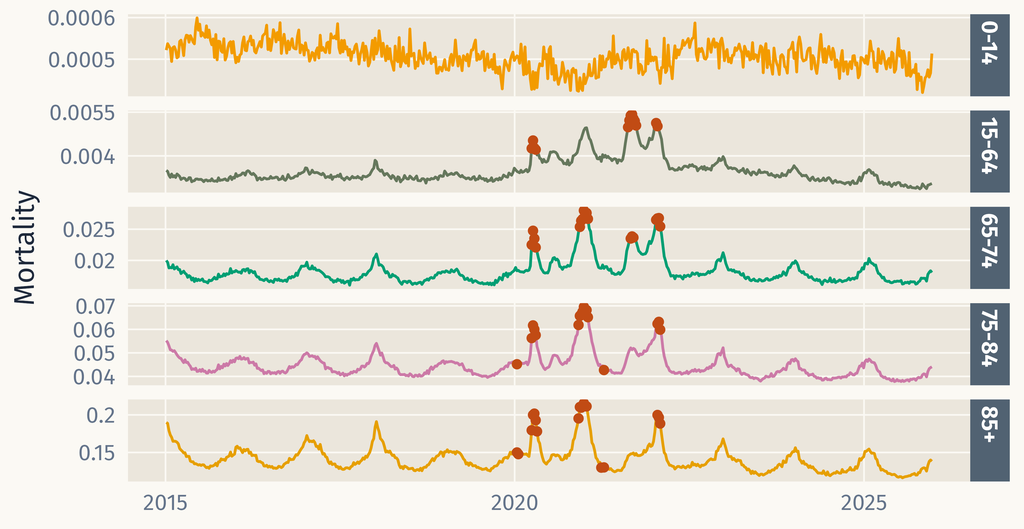

## US weekly mortality rates

[interactive chart not shown]

## Weird series

03

1. Surprisals
2. Weird times
3. Weird series
4. Surveillance
5. Summary

## Australian Pharmaceutical Benefits Scheme

```r
PBS <- tsibbledata::PBS |>
  update_tsibble(key = c(Concession, Type, ATC2)) |>
  select(Month, Concession, Type, ATC2, Scripts)
PBS
```

```
# A tsibble: 67,596 x 5 [1M]
# Key:       Concession, Type, ATC2 [336]
      Month Concession   Type        ATC2  Scripts
      <mth> <chr>        <chr>       <chr>   <dbl>
 1 1991 Jul Concessional Co-payments A01     18228
 2 1991 Aug Concessional Co-payments A01     15327
 3 1991 Sep Concessional Co-payments A01     14775
 4 1991 Oct Concessional Co-payments A01     15380
 5 1991 Nov Concessional Co-payments A01     14371
 6 1991 Dec Concessional Co-payments A01     15028
 7 1992 Jan Concessional Co-payments A01     11040
 8 1992 Feb Concessional Co-payments A01     15165
 9 1992 Mar Concessional Co-payments A01     16898
10 1992 Apr Concessional Co-payments A01     18141
# ℹ 67,586 more rows
```

## How do we compare 336 time series?

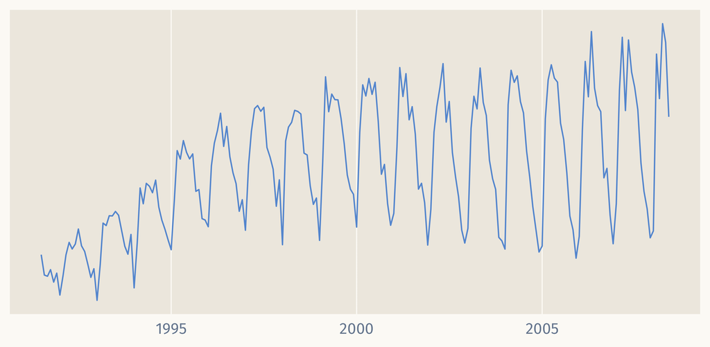

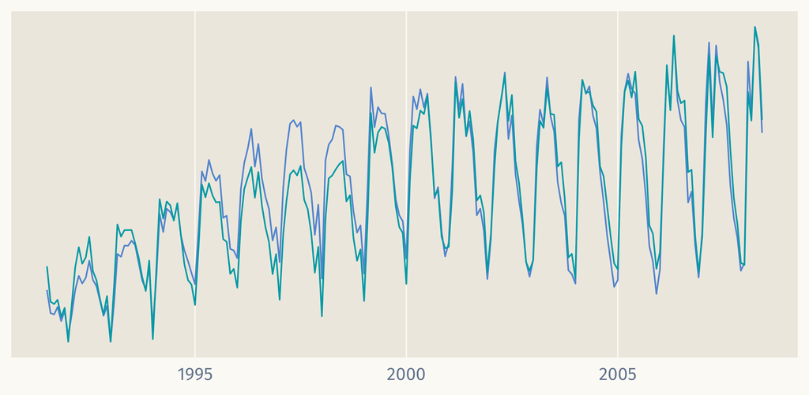

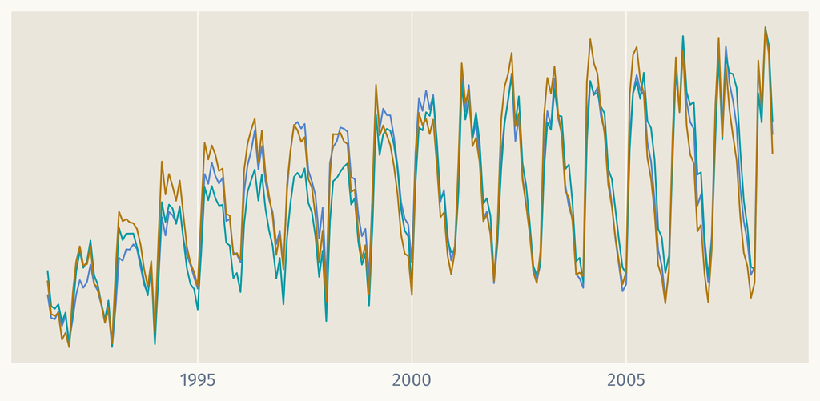

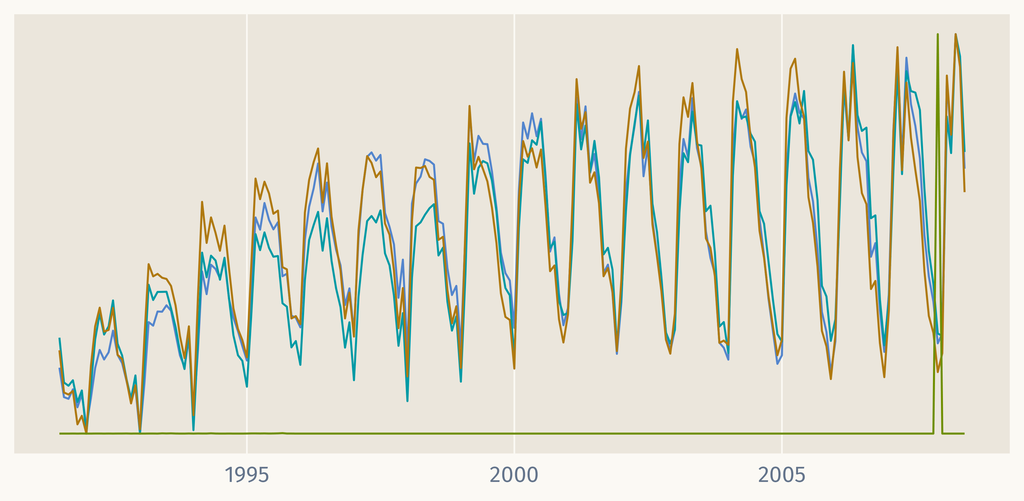

[video not shown]

## Feature: strength of trend

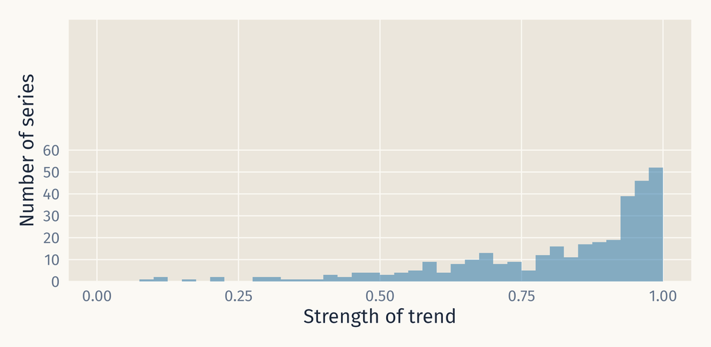

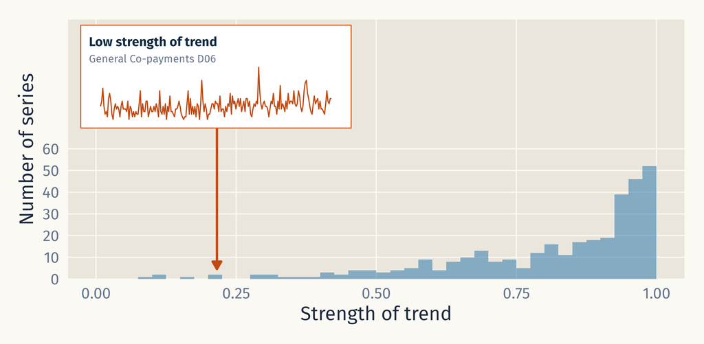

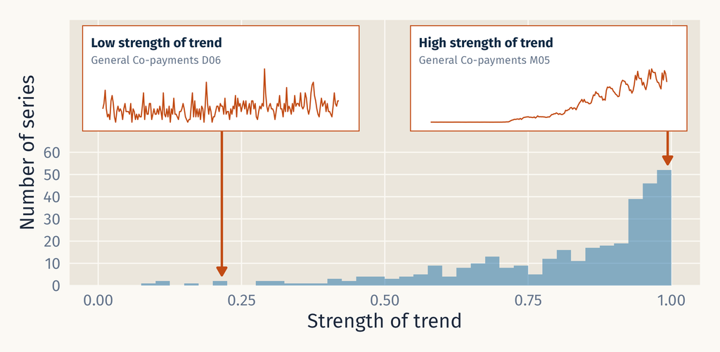

## Feature: strength of seasonality

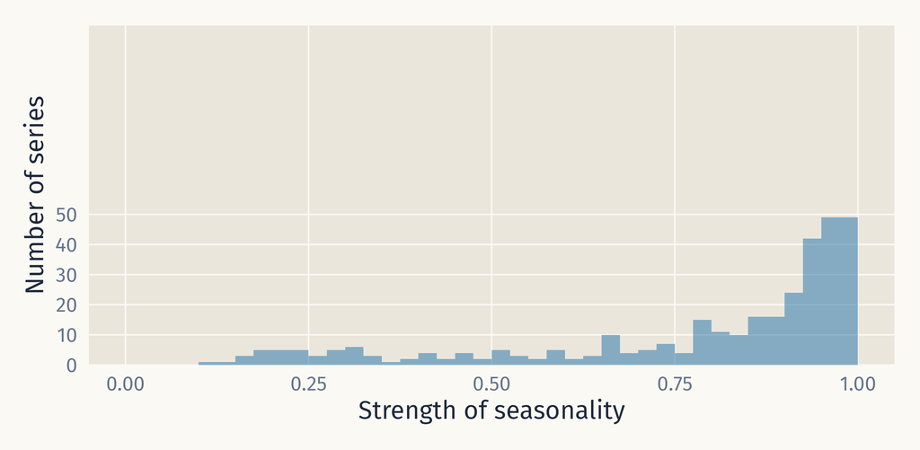

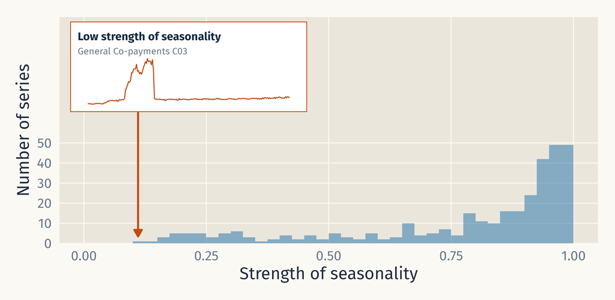

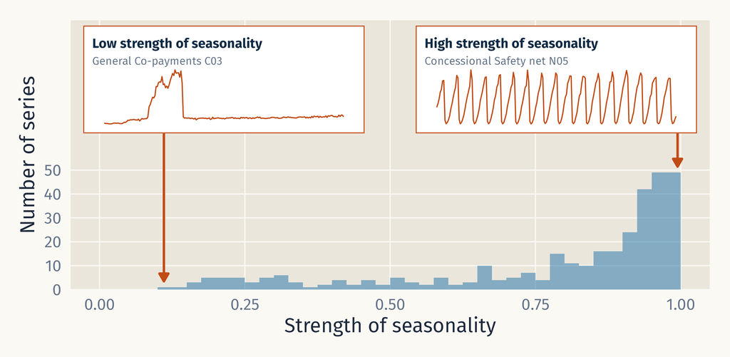

## Feature space

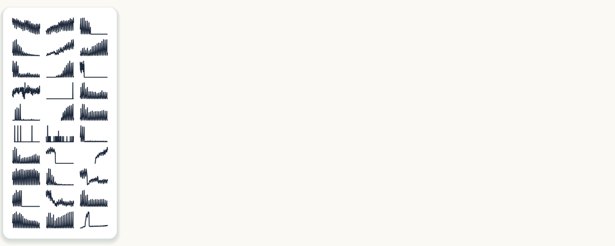

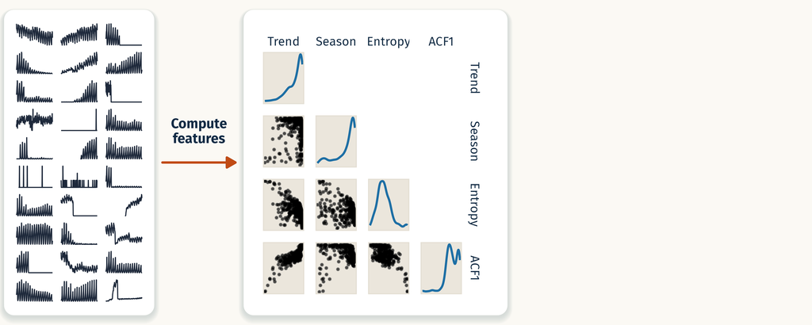

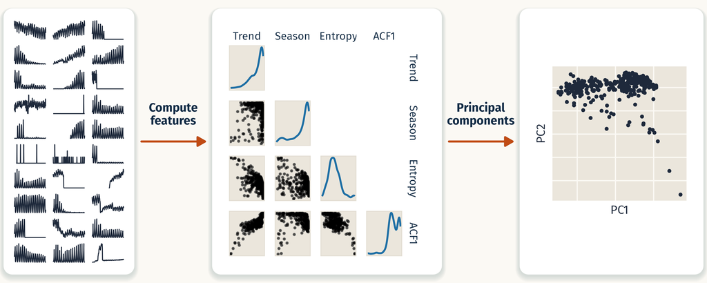

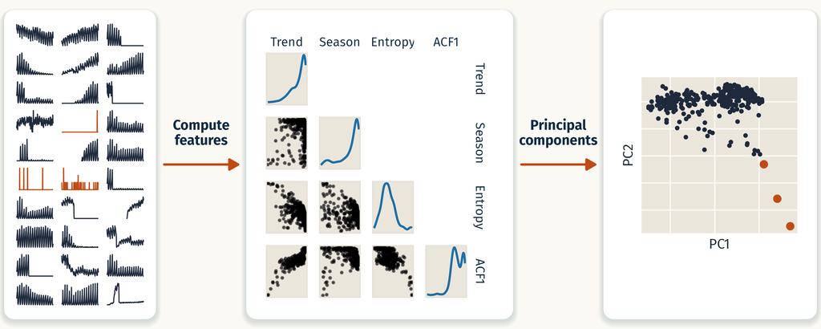

A weird series is an anomaly in feature space. Features are mostly scale-free, so series are flagged for their shape and dynamics, not their size.

## Australian Pharmaceutical Benefits Scheme

```r
PBS_feat <- PBS |>
  features(Scripts, feature_set(pkgs = "feasts"))
```

```
# A tibble: 336 × 51
  Concession   Type        ATC2  trend_strength seasonal_strength_year
  <chr>        <chr>       <chr>          <dbl>                  <dbl>
1 Concessional Co-payments A01            0.845                  0.918
2 Concessional Co-payments A02            0.970                  0.943
3 Concessional Co-payments A03            0.956                  0.931
# ℹ 333 more rows
# ℹ 46 more variables: seasonal_peak_year <dbl>, seasonal_trough_year <dbl>,
#   spikiness <dbl>, linearity <dbl>, curvature <dbl>, stl_e_acf1 <dbl>,
#   stl_e_acf10 <dbl>, acf1 <dbl>, acf10 <dbl>, diff1_acf1 <dbl>,
#   diff1_acf10 <dbl>, diff2_acf1 <dbl>, diff2_acf10 <dbl>, season_acf1 <dbl>,
#   pacf5 <dbl>, diff1_pacf5 <dbl>, diff2_pacf5 <dbl>, season_pacf <dbl>,
#   zero_run_mean <dbl>, nonzero_squared_cv <dbl>, zero_start_prop <dbl>, …
```

336 series, 48 features each; 3 series have missing features.